# Admissions model 3

David Henderson

07, March, 2019

# Introduction

*new model using cleaned sc data 2019-03-03*

Same drill as with social care models but dependent variable is any usc in 6 months after end of financial year and adding social care in as an independent variable. I’m doing this for the whole cohort again but without councils or health boards - they have little effect.

## Packages

```r
library(finalfit)  #Easy summary and OR tables
library(tidyverse) #For ...well everything
library(magrittr)  #Pipe operators
library(lubridate) #Dates (not loaded with tidyverse)
library(broom)     #Tidy model coefficients and fit stats
library(extrafont) #For plot font options
library(margins)   #Calculate AMEs from models
library(DT)        #Print pretty tables in html with buttons
library(ggthemes)  #scale_colour_ptol()
library(ggrepel)
library(rlang)
library(glue)

#Set the base plotting options
theme_set(theme_minimal(base_size = 16))

#My own helper functions
`%nin%` <- Negate(`%in%`) #negate the %in% function
source("Research/functions/round_df.R") #Round-up all numeric values in a df
source("Research/functions/my_datatable.R") #quick datatable

#From @kjhealy's book "Data visualisation"
#Two functions to tidy up variable names in model outputs
source("Research/functions/prefix_funcs.R")

#As of October 2018 I am using margins v0.3.23. An update in
#August 2018 included the below function to summarise the margins command
#in a way that can be mapped using purrr::map. This has not been pushed
#to CRAN yet and there will be delay even after it is before it will be
#available in the safe haven. It is fairly simple so have recreated it here
source("Research/functions/margins_summary.R")

#Set breaks and labels for plots here (saves re-writing them for
#facet plots etc.)
year_breaks <- c(ymd(20110331), ymd(20120331), ymd(20130331),
                 ymd(20140331), ymd(20150331), ymd(20160331))

year_labels <- c(`2011-03-31` = "2010/11",
                 `2012-03-31` = "2011/12",
                 `2013-03-31` = "2012/13",
                 `2014-03-31` = "2013/14",
                 `2015-03-31` = "2014/15",
                 `2016-03-31` = "2015/16")
#Finally an expression that can be used programatically with case_when()
#note: needs library(rlang)
year_char <- exprs(
           year == ymd(20110331) ~ "2010/11",
           year == ymd(20120331) ~ "2011/12",
           year == ymd(20130331) ~ "2012/13",
           year == ymd(20140331) ~ "2013/14",
           year == ymd(20150331) ~ "2014/15",
           year == ymd(20160331) ~ "2015/16",
           year == ymd(20170331) ~ "2016/17"
)

#Set a file path for saving objects

filepath <- "Research/created_objects/models/"
```

## Load data

Using the `thesis_usc` object.

```r
load("Research/created_objects/clean_data/thesis_usc.rds")
```

# Tidy up

- Drop those that died (in current year so couldn’t have usc in next year!)

```r
thesis_usc %<>%
  #Drop those that dies in *current* year
  filter(is.na(dod)) %>%
  #Drop variables not in the model
  select(index, year, usc_six, sex, age_grp, simd, meds_grp,
         scs_flag, usc_flag, care_home)

#Coerce usc_six from logical to factor
thesis_usc$usc_six <- factor(thesis_usc$usc_six)
```

# Admission model 3

## Summarise variables

- Create a summary table. I want a summary table for each year of data.

```r
#Name variables
explanatory = c("sex", "age_grp", "simd", "meds_grp", "scs_flag",
                "usc_flag", "care_home")
dependent = "usc_six"
#Nest dataframe by year then apply summary_factorlist()
thesis_usc %>%
  group_by(year) %>%
  nest(.key = "year_data") %>%
  mutate(tab = map(year_data,
                   summary_factorlist,
                   dependent, explanatory,
                   add_dependent_label = TRUE,
                   dependent_label_prefix = "",
                   p = TRUE,
                   total_col = TRUE,
                   cont = "median")) -> usc_table_1
#Pull correct labels out into a vector
V1_labels <- usc_table_1$tab[[1]][[2]]
#Apply these labels repeatedly for the 5 year of data and
#drop uneccessary empty variables. Also rename year data to better labels
usc_table_1 %<>%
  unnest(tab, .drop = TRUE) %>%
  arrange(year) %>%
  mutate(V1 = rep(V1_labels,5),
         year = case_when(!!!year_char)) %>%
  select(-(V2:V5))
```

Print out a table for 2015/16 only

```r
usc_table_1 %>%
  filter(year == "2015/16") %>%
  my_datatable(.)
```

|  | year | usc_six | V1 | FALSE | TRUE | Total | p |
| --- | --- | --- | --- | --- | --- | --- | --- |
| 1 | 2015/16 | sex | Male | 325701 (81.8) | 72660 (18.2) | 398361 | &lt;0.001 |
| 2 | 2015/16 |  | Female | 391058 (80.1) | 96912 (19.9) | 487970 |  |
| 3 | 2015/16 | age_grp | 65-69 | 242658 (87.1) | 35955 (12.9) | 278613 | &lt;0.001 |
| 4 | 2015/16 |  | 70-74 | 178736 (84.7) | 32176 (15.3) | 210912 |  |
| 5 | 2015/16 |  | 75-79 | 135508 (80.3) | 33157 (19.7) | 168665 |  |
| 6 | 2015/16 |  | 80-84 | 91240 (74.6) | 31112 (25.4) | 122352 |  |
| 7 | 2015/16 |  | 85-89 | 47315 (67.6) | 22699 (32.4) | 70014 |  |
| 8 | 2015/16 |  | 90-94 | 17140 (60.5) | 11171 (39.5) | 28311 |  |
| 9 | 2015/16 |  | 95 plus | 4162 (55.8) | 3302 (44.2) | 7464 |  |
| 10 | 2015/16 | simd | 1 | 54957 (75.4) | 17934 (24.6) | 72891 | &lt;0.001 |

[output cut: 19 more lines]

## Fit the model to all years

First coerce simd to numeric and calculate mean and sd

```r
thesis_usc %<>%
  mutate(simd = as.numeric(simd))

thesis_usc %>%
  summarise(mean_simd = mean(simd),
            sd_simd = sd(simd))
```

| mean_simd | sd_simd |
| --- | --- |
| 5.552777 | 2.801679 |

Now I am going to use the `or_plot()` function from `finalfit` to produce a nice plot showing odds ratios. As this isn’t a `ggplot` I can’t save it in the normal manner so will use the `png()` function instead. This means it won’t render in the html but I’ll leave the code in here for reference.

Formula for this model: `glm(usc_six ~ sex*age_grp + simd*meds_grp + age_grp*meds_grp + scs_flag*age_grp + usc_flag + care_home`

```r
start <- Sys.time()
#Name variables
explanatory = c("sex*age_grp", "simd*meds_grp",
                "age_grp*meds_grp", "scs_flag*age_grp",
                "usc_flag", "care_home")
dependent = "usc_six"

png("Research/created_objects/plots/usc_model_5_or_plot.png",
    width = 12, height = 9, units = "in", res = 300)

thesis_usc %>%
  filter(year == ymd(20160331)) %>%
  mutate(scs_flag = ff_label(scs_flag, "Any social care"),
         sex = ff_label(sex, "Sex"),
         age_grp = ff_label(age_grp, "Age group"),
         simd = ff_label(simd, "SIMD"),
         meds_grp = ff_label(meds_grp, "Repeat medicine group"),
         usc_flag = ff_label(usc_flag, "Previous USC use"),
         care_home = ff_label(care_home, "Residence")) %>%
  or_plot(dependent, explanatory,
          dependent_label = "Any USC episode in the 6 months after end 2015/16",
          breaks = c(0.5, 1, 2, 5, 10))

dev.off()
print(Sys.time()-start)
```

```r
start <- Sys.time()

#Create a function for the model
adm_model <- function(my_df){
  glm(usc_six ~                                #The formula for the model
        sex*age_grp +
        simd*meds_grp +
        age_grp*meds_grp +
        scs_flag*age_grp +
        usc_flag +
        care_home,
      family = binomial(),                      #Logistic regression
      data = my_df)                             #identify which data to use
  }

usc_model_5 <-
  thesis_usc %>%  #Main dataframe
  group_by(year) %>%
  #Nest data for each year
  nest(.key = "year_data") %>%
  #Create model column using above function
  mutate(mod_var = map(year_data, adm_model),
         #Tidy coefficients using broom::tidy into a column
         tidy_var = map(mod_var, tidy),
         #compute AMEs and add as a column
         marginals = map2(mod_var, year_data, ~margins_summary(.x, data = .y)))

print(Sys.time()-start)
```

```r
save(usc_model_5, file = "Research/created_objects/models/usc_model_5.rds")
```

*Note: Time difference = 8.3 hrs*

## Model Summary

```r
usc_model_5 %>%
  filter(year == ymd(20160331)) %>%
  unnest(tidy_var, .drop = TRUE) %>%
  #exponentiate the coefficents for OR
  mutate(odds_ratio = exp(estimate),
         #Calculate Lower CI and exponentiate
         conf_int_low = exp(estimate - 1.96*std.error),
         #Calculate Upper CI and exponentiate
         conf_int_high = exp(estimate + 1.96*std.error)) %>%
  round_df(., dig = 3) %>%
  mutate(p.value = as.character(p.value),
         p.value = if_else(p.value == "0", "<0.001", p.value)) -> tidy_tab

#Tidy up labels
prefixes <- c("sex", "scs_flag", "usc_flag", "care_home")
tidy_tab$term <- prefix_strip(tidy_tab$term, prefixes)
tidy_tab$term <- prefix_replace(tidy_tab$term, "Meds_grp",
                                       "Meds: ")
tidy_tab$term <- prefix_replace(tidy_tab$term,
                                       "Age_grp", "Age: ")
tidy_tab$term <- prefix_replace(tidy_tab$term,
                                       "Simd", "SIMD Decile: ",
                                       toTitle = FALSE)

#tidy_tab
my_datatable(tidy_tab)
```

|  | year | term | estimate | std.error | statistic | p.value | odds_ratio | conf_int_low | conf_int_high |
| --- | --- | --- | --- | --- | --- | --- | --- | --- | --- |
| 1 | 2016-03-31 | (Intercept) | -2.471 | 0.02 | -123.49 | &lt;0.001 | 0.084 | 0.081 | 0.088 |
| 2 | 2016-03-31 | Female | -0.018 | 0.012 | -1.537 | 0.124 | 0.982 | 0.96 | 1.005 |
| 3 | 2016-03-31 | Age: 70-74 | 0.089 | 0.02 | 4.345 | &lt;0.001 | 1.093 | 1.05 | 1.137 |
| 4 | 2016-03-31 | Age: 75-79 | 0.318 | 0.023 | 13.996 | &lt;0.001 | 1.375 | 1.315 | 1.437 |
| 5 | 2016-03-31 | Age: 80-84 | 0.553 | 0.026 | 20.928 | &lt;0.001 | 1.738 | 1.65 | 1.83 |
| 6 | 2016-03-31 | Age: 85-89 | 0.817 | 0.033 | 24.697 | &lt;0.001 | 2.263 | 2.121 | 2.415 |
| 7 | 2016-03-31 | Age: 90-94 | 1.228 | 0.048 | 25.833 | &lt;0.001 | 3.415 | 3.111 | 3.749 |
| 8 | 2016-03-31 | Age: 95 Plus | 1.207 | 0.09 | 13.339 | &lt;0.001 | 3.343 | 2.8 | 3.991 |
| 9 | 2016-03-31 | SIMD Decile: | -0.024 | 0.003 | -9.52 | &lt;0.001 | 0.976 | 0.971 | 0.981 |
| 10 | 2016-03-31 | Meds: 3-5 | 0.298 | 0.025 | 11.914 | &lt;0.001 | 1.347 | 1.282 | 1.414 |

[output cut: 38 more lines]

Mostly for checking p-values. Interaction between SIMD and all meds groups isn’t statistically significant. A few others as well. Mainly low age and low meds interactions.

### Fit statistics

Create new list column to model object with fit statistics using `broom::glance`

```r
usc_model_5 %<>%
  mutate(glance_var = map(mod_var, glance))
```

Now I need to mannually calcluate McFadden’s pseudo $R^{2}$ which has the formula:

$$R^{2}_{McFadden} = 1 - \frac {ln(LM_{1})}{ln(LM_{0})}$$

Where, $ln(LM_{1})$ is the log likelihood value for the fitted model and $ln(LM_{0})$ is the log likelihood for the null model with only an intercept as a predictor.

Calculate the pseudo $R^2$, then rearrange variable order whilst dropping unwanted variables from glance - Print this out - will need reported.

```r
usc_model_5 %>%
  #unnest the list column of fit stats
  unnest(glance_var, .drop = TRUE) %>%
  arrange(year) %>%
  #Calculate McFadden's pseudo R2
  mutate(pseud_r2 = 1 - (logLik / (null.deviance / -2)),
         year = case_when(!!!year_char)) %>%
  #Add a variable showing logLik of null model
  mutate(null.logLik = null.deviance / -2) %>%
  #Rearrange and drop variables
  select(year, pseud_r2, deviance, logLik, df.residual,
         null.deviance, null.logLik,  df.null) %>%
  #Round everything to 3 decimal places
  round_df(dig = 3)-> gof_tab

#gof_tab
my_datatable(gof_tab)
```

|  | year | pseud_r2 | deviance | logLik | df.residual | null.deviance | null.logLik | df.null |
| --- | --- | --- | --- | --- | --- | --- | --- | --- |
| 1 | 2011/12 | 0.102 | 713457.192 | -356728.596 | 821187 | 794815.466 | -397407.733 | 821234 |
| 2 | 2012/13 | 0.104 | 723175.916 | -361587.958 | 841129 | 807122.378 | -403561.189 | 841176 |
| 3 | 2013/14 | 0.112 | 756309.484 | -378154.742 | 858910 | 851221.849 | -425610.924 | 858957 |
| 4 | 2014/15 | 0.113 | 759602.005 | -379801.002 | 870332 | 856020.083 | -428010.041 | 870379 |
| 5 | 2015/16 | 0.111 | 765923.232 | -382961.616 | 880446 | 861998.078 | -430999.039 | 880493 |

Anything with pseudo $R^2$ 0.2-0.4 is considered a very good fit. Again, values are not as good as for social care models but still ok(ish).

### Residual assessment

Not excpecting normally distributed residuals or constant variance as I am using a non-linear model. However, can have a look at the deviance residual to see if indiviudal points are not well fitted.

I use `augment()` from `broom` to find values then plot the standardised residuals to see how many exceed 3 standard deviations.

```r
#Add fitted values (and associated stats) to every observation
usc_model_5 %<>%
  mutate(aug_var = map(mod_var, augment))
```

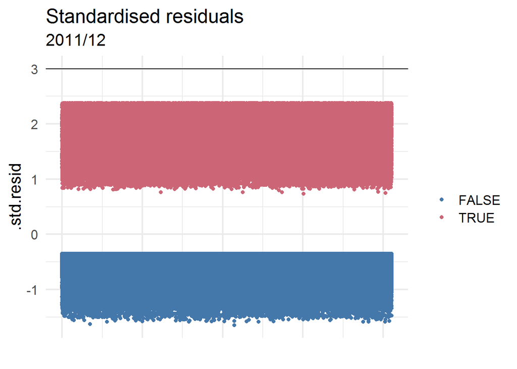

```r
usc_model_5 %>%
  filter(year == ymd(20120331)) %>%
  unnest(.$aug_var) %>%
  mutate(index = 1:n())-> aug_data_1112

aug_data_1112 %>%
  ggplot(aes(index, .std.resid, colour = usc_six)) +
  geom_point() +
  geom_hline(yintercept = 3) +
  scale_colour_ptol() +
  theme(axis.text.x = element_blank()) + #supress index for SDC
  labs(title = "Standardised residuals",
       subtitle = "2011/12",
       colour = "",
       x = "")
```

Once more, poor $R^2$ values but residuals look better than social care models! Whatever..

## Marginal effects

Now to look at AMEs

```r
usc_model_5 %>%
  unnest(marginals) %>%
  round_df(dig = 3) %>%
  arrange(year, AME) %>%
  mutate(order = row_number())-> usc_marginal


#Tidy up labels
prefixes <- c("sex")
usc_marginal$factor <- prefix_strip(usc_marginal$factor, prefixes)
usc_marginal$factor <- prefix_replace(usc_marginal$factor, "Meds_grp",
                                       "Meds: ")
usc_marginal$factor <- prefix_replace(usc_marginal$factor,
                                       "Age_grp", "Age: ")
usc_marginal$factor <- prefix_replace(usc_marginal$factor,
                                       "Simd", "SIMD Decile: ",
                                       toTitle = FALSE)
usc_marginal$factor <- prefix_replace(usc_marginal$factor,
                                       "scs_flag", "")
usc_marginal$factor <- prefix_replace(usc_marginal$factor,
                                       "usc_flag", "")
usc_marginal$factor <- prefix_replace(usc_marginal$factor,
                                       "care_home", "")
#usc_marginal
my_datatable(usc_marginal)
```

|  | year | factor | AME | SE | z | p | lower | upper | order |
| --- | --- | --- | --- | --- | --- | --- | --- | --- | --- |
| 1 | 2012-03-31 | Female | -0.011 | 0.001 | -13.596 | 0 | -0.013 | -0.01 | 1 |
| 2 | 2012-03-31 | SIMD Decile: | -0.003 | 0 | -20.143 | 0 | -0.003 | -0.003 | 2 |
| 3 | 2012-03-31 | Age: 70-74 | 0.007 | 0.001 | 5.878 | 0 | 0.005 | 0.01 | 3 |
| 4 | 2012-03-31 | Age: 75-79 | 0.026 | 0.001 | 19.871 | 0 | 0.023 | 0.028 | 4 |
| 5 | 2012-03-31 | Meds: 3-5 | 0.031 | 0.001 | 27.275 | 0 | 0.029 | 0.034 | 5 |
| 6 | 2012-03-31 | Age: 80-84 | 0.053 | 0.001 | 35.672 | 0 | 0.05 | 0.056 | 6 |
| 7 | 2012-03-31 | Meds: 6-8 | 0.066 | 0.001 | 53.475 | 0 | 0.064 | 0.069 | 7 |
| 8 | 2012-03-31 | Care Home | 0.069 | 0.002 | 32.706 | 0 | 0.064 | 0.073 | 8 |
| 9 | 2012-03-31 | Age: 85-89 | 0.081 | 0.002 | 40.84 | 0 | 0.077 | 0.085 | 9 |
| 10 | 2012-03-31 | Social Care | 0.104 | 0.002 | 54.25 | 0 | 0.1 | 0.108 | 10 |

[output cut: 60 more lines]

70 rows here again- not explicitly going to report these as I show them in the plot, but I do want a table with *actual* values that I can refer too. The values (particularly in higher age bands) get larger in 2014/14 and 2015/16. This is likely due to the fact there is more (better) data in the SCS which included telecare/alarms at any time in financial year rather than just in census week. I’ll need to discuss this so need the numbers.

## Plot marginal effects

Plot the table

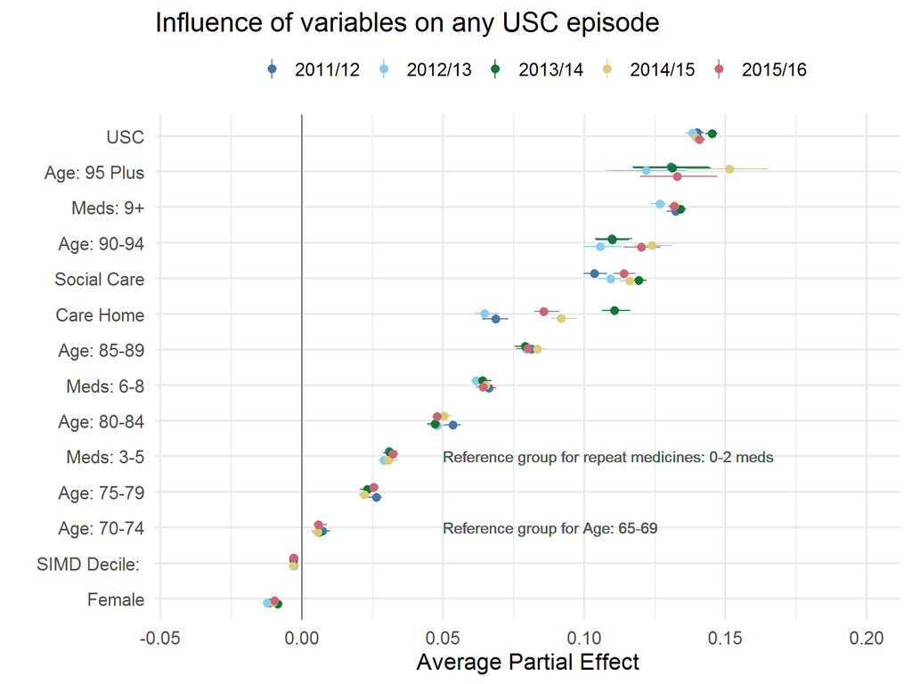

```r
usc_marginal %>%
  ggplot(aes(reorder(factor, AME), AME,
             ymin = lower, ymax = upper,
             colour = factor(year))) +
  geom_hline(yintercept = 0, colour = "#555555") +
  geom_pointrange(fatten = 4, position = position_jitter(width = 0.15)) +
  geom_text(aes(x = "Age: 70-74", y= 0.05),
             label = "Reference group for Age: 65-69",
             colour = "#555555",
             hjust = 0) +
  geom_text(aes(x = "Meds: 3-5", y = 0.05),
             label = "Reference group for repeat medicines: 0-2 meds",
             colour = "#555555",
             hjust = 0) +
  coord_flip() +
  scale_colour_ptol(labels = year_labels) +
  scale_y_continuous(limits = c(-0.04, 0.2),
                     breaks = scales::pretty_breaks(n = 8)) +
  theme(legend.position = "top") +
  labs(x = "",
       y= "Average Partial Effect",
       colour = "",
       title = "Influence of variables on any USC episode") -> usc_model_5_AME_plot

usc_model_5_AME_plot
```

## Plot SIMD

SIMD id different from the rest as it is modelled as a continuous variable. I’m going to produce a separate plot for it to make interpretation easier.

```r
usc_model_5 %<>%
  mutate(cplot_simd = map2(mod_var, year_data,
                           ~cplot(.x, data = .y, x = "simd", draw=FALSE)))
```

```r
usc_model_5 %>%
  filter(year == ymd(20160331)) %>%
  unnest(cplot_simd) %>%
  round_df(., dig=3) %>%
  my_datatable(.)
```

|  | year | xvals | yvals | upper | lower |
| --- | --- | --- | --- | --- | --- |
| 1 | 2016-03-31 | 1 | 0.099 | 0.101 | 0.096 |
| 2 | 2016-03-31 | 1.375 | 0.098 | 0.101 | 0.095 |
| 3 | 2016-03-31 | 1.75 | 0.097 | 0.1 | 0.095 |
| 4 | 2016-03-31 | 2.125 | 0.097 | 0.099 | 0.094 |
| 5 | 2016-03-31 | 2.5 | 0.096 | 0.099 | 0.094 |
| 6 | 2016-03-31 | 2.875 | 0.095 | 0.098 | 0.093 |
| 7 | 2016-03-31 | 3.25 | 0.095 | 0.097 | 0.092 |
| 8 | 2016-03-31 | 3.625 | 0.094 | 0.096 | 0.092 |
| 9 | 2016-03-31 | 4 | 0.094 | 0.096 | 0.091 |
| 10 | 2016-03-31 | 4.375 | 0.093 | 0.095 | 0.091 |

[output cut: 15 more lines]

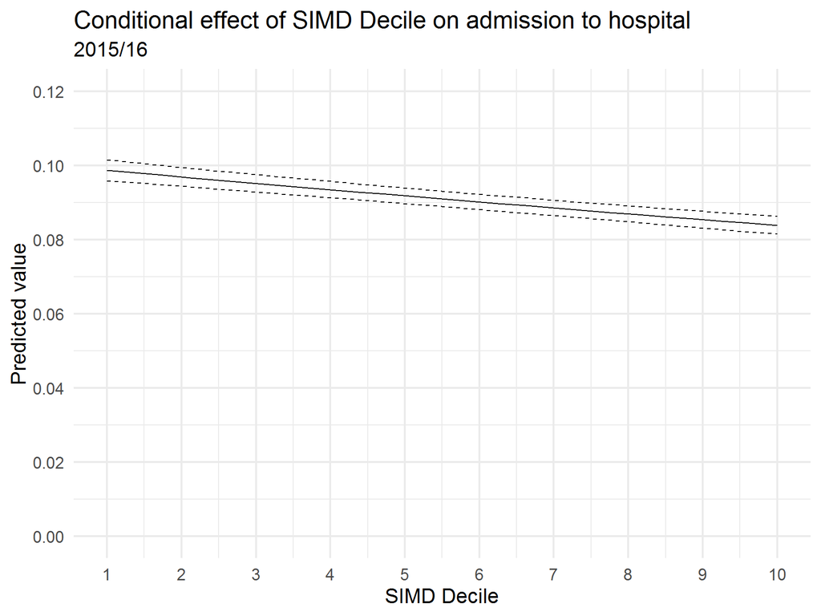

```r
usc_model_5 %>%
  filter(year == ymd(20160331)) %>%
  unnest(cplot_simd) %>%
  ggplot(aes(x = xvals)) +
  geom_line(aes(y = yvals)) +
  geom_line(aes(y = upper), linetype = 2) +
  geom_line(aes(y = lower), linetype = 2) +
  scale_x_continuous(breaks = scales::pretty_breaks(n = 10)) +
  scale_y_continuous(breaks = scales::pretty_breaks(),
                     limits = c(0, 0.12)) +
  labs(title = "Conditional effect of SIMD Decile on admission to hospital",
       subtitle = "2015/16",
       x = "SIMD Decile",
       y = "Predicted value") -> usc_model_5_simd_plot
usc_model_5_simd_plot
```

```r
ggsave("Results/2019-03-04/usc_model_5_simd_plot.png",
       usc_model_5_simd_plot, width = 9, height = 6.75, dpi = 600)
```